# Library tutorial

# Survival data analyses

In this two examples we fit an exposure-response curve on survival data at final time. In the first one we use a dataset with survival data at final time. In the second one we use dataset comes from reproduction data.

## From survival data at final time

- Step one, check the structure and the dataset integrity

The dataset of survival data at final time must contain at least three columns with the mesured concentrations, the initial number of individuals at the beginning of the bioassai and the number of survivals at the mesured time.

We start be create a dataset of five mesured concentrations plus the control and check is integrity.

```r
dat3 <- data.frame(conc = c(0, 0.18, 0.73, 1.82, 2.9, 7),
        Ninit = as.integer(c(10, 10, 10, 10, 10, 10)),
        Nsurv = as.integer(c(10, 9, 9, 9, 3, 2)))
surv.tt.check.data(dat3)
```

```
## The dataframe seems to be correct !
```

- Step two, create an object `surv.tt.data()` object

To analyse this dataset it is necessary to transform it to an object of class `surv.tt.data`. The `summary()` provides informations on the experimental design.

```r
dat4 <- surv.tt.data(dat3)
dat4
```

```
##
##
## Transformed data:
##   replicate conc Ninit Nsurv
## 1         A 0.00    10    10
## 2         A 0.18    10     9
## 3         A 0.73    10     9
## 4         A 1.82    10     9
## 5         A 2.90    10     3
## 6         A 7.00    10     2
##
##
## Target time:
## [1] "NA"
```

```r
summary(dat4)
```

```
## Summary:
##
##
##
## Transformed data:
##
## Number of survival per concentration and replicate:
##       A
## 0    10
## 0.18  9
## 0.73  9
## 1.82  9
## 2.9   3
## 7     2
##
## Number of datapoints per concentration:
##
##    0 0.18 0.73 1.82  2.9    7
##    1    1    1    1    1    1
```

- Step three, fit an exposure-response model to the survival data at final time

Now the dataset with survival data at final time is created it is possible to estimate the parameters of the log-logistic exposure-response model with the `surv.tt.fit()` function. This function calls the `JAGS` program to estimate the model parameters using the bayesian inference.

```r
out3 <- surv.tt.fit(dat4, det.part = "loglogisticbinom_2",
        lcx = c(10, 20, 30, 40, 50))
```

The median and 2.5 % and 97.5 % of priors and posteriors on estimated parameter distributions and on $LC_{x}$ estimates are given by the `summary()`. The function `plot()` draws the exposure-response curve with the credible limits superimposed to experimental data at final time.

```r
summary(out3)
```

```
## Summary:
##
## The  loglogisticbinom_2  model with a binomial stochastic part
##                  was used !
##
## Quantiles of priors on parameters:
##
##     50%  2.5% 97.5%
## b 1.557 0.105 3.008
## e 2.238 1.486 2.989
##
## Quantiles of posteriors on parameters:
##
##     50%  2.5% 97.5%
## b 1.169 0.476 2.103
## e 2.691 1.496 5.276
##
## Quantiles of the estimated LCx:
##
##        50%  2.5% 97.5%
## LC10 0.411 0.027 1.031
## LC20 0.820 0.143 1.626
## LC30 1.299 0.406 2.299
## LC40 1.899 0.867 3.315
## LC50 2.691 1.496 5.276
```

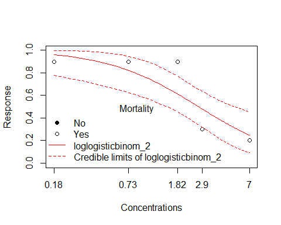

```r
plot(out3, log.scale = TRUE, ci = TRUE)
```

- Step four, check the the convergence of the MCMC chains

The function `convergence()` can be used to check the convergence of the MCMC chains from the `JAGS` estimate with the Gelman and Rubin convergence diagnostic, to draw the MCMC value, the density of posteriors or the autocorrelation for each parameter in each chain.

```r
convergence(out3, trace = FALSE, autocorr = FALSE)
```

```
## Gelman and Rubin:
## Potential scale reduction factor for each parameter:
##   log10b   log10e
## 1.003972 1.000414
##
## Multivariate potential scale reduction factor:
##  1.000462
```

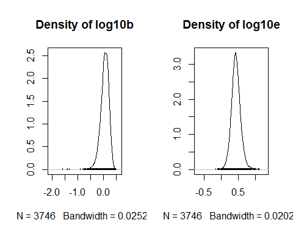

## From reproduction data

The two first parts are the sames as the reproduction analysis.

- Step one, check the structure and the dataset integrity

```r
data(cadmium1)
repro.check.data(cadmium1, diagnos.plot = TRUE)
```

```
## The dataframe seems to be correct !
```

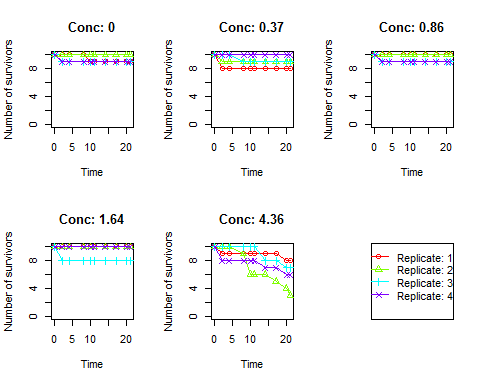

```r
repro.fullsurvplot(cadmium1)
```

- Step two, create a `repro.data` object

```r
dat5 <- repro.data(cadmium1)
```

- Step three, create a `surv.tt.data` object from a `repro.data` object

The function `repro2survtt()` transforms an object of class `repro.data` to an object of class `surv.tt.data`.

```r
dat6 <- repro2survtt(dat5)
dat6
```

```
##
##
## Transformed data:
##    replicate conc Ninit Nsurv
## 1          1 0.00    10     9
## 2          1 0.37    10     8
## 3          1 0.86    10    10
## 4          1 1.64    10    10
## 5          1 4.36    10     8
## 6          2 0.00    10    10
## 7          2 0.37    10     9
## 8          2 0.86    10    10
## 9          2 1.64    10    10
## 10         2 4.36    10     3
## 11         3 0.00    10     9
## 12         3 0.37    10     9
## 13         3 0.86    10     9
## 14         3 1.64    10     8
## 15         3 4.36    10     7
## 16         4 0.00    10     9
## 17         4 0.37    10    10
## 18         4 0.86    10     9
## 19         4 1.64    10    10
## 20         4 4.36    10     6
##
##
## Target time:
## [1] 21
```

```r
summary(dat6)
```

```
## Summary:
##
## Raw data:
##
## Number of replicate by time and concentration:
##       time
## conc   0 2 4 8 10 11 14 17 20 21
##   0    4 4 4 4  4  4  4  4  4  4
##   0.37 4 4 4 4  4  4  4  4  4  4
##   0.86 4 4 4 4  4  4  4  4  4  4
##   1.64 4 4 4 4  4  4  4  4  4  4
##   4.36 4 4 4 4  4  4  4  4  4  4
##
## Number of survival (sum of replicate) per time and concentration:
##       0  2  4  8 10 11 14 17 20 21
## 0    40 38 38 38 37 37 37 37 37 37
## 0.37 40 37 37 36 36 36 36 36 36 36
## 0.86 40 38 38 38 38 38 38 38 38 38
## 1.64 40 38 38 38 38 38 38 38 38 38
## 4.36 40 37 37 36 33 33 30 29 25 24
##
## Number of datapoints per concentration:
##
##    0 0.37 0.86 1.64 4.36
##   40   40   40   40   40
##
## Number of datapoints per time:
##
##  0  2  4  8 10 11 14 17 20 21
## 20 20 20 20 20 20 20 20 20 20
##
##
## Transformed data:
##
## Number of survival per concentration and replicate:
##       1  2 3  4
## 0     9 10 9  9
## 0.37  8  9 9 10
## 0.86 10 10 9  9
## 1.64 10 10 8 10
## 4.36  8  3 7  6
##
## Number of datapoints per concentration:
##
##    0 0.37 0.86 1.64 4.36
##    4    4    4    4    4
```

- Step four, fit an exposure-response model to the survival data at final time

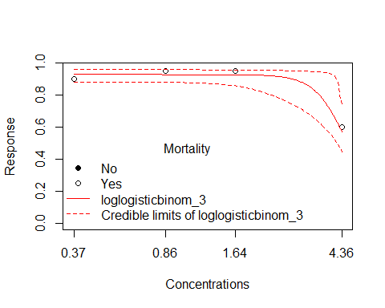

```r
out4 <- surv.tt.fit(dat6, det.part = "loglogisticbinom_3",
        lcx = c(10, 20, 30, 40, 50))
summary(out4)
plot(out4, log.scale = TRUE, ci = TRUE)
```

[output not shown]

- Step five, check the the convergence of the MCMC chains

```r
convergence(out4, trace = FALSE, autocorr = FALSE)
```

```
## Gelman and Rubin:
## Potential scale reduction factor for each parameter:
##        d   log10b   log10e
## 1.000209 1.000328 1.001296
##
## Multivariate potential scale reduction factor:
##  1.001256
```

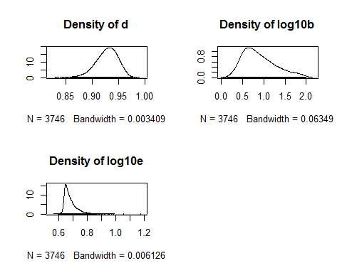